# Praca domowa 7

Łukasz Brzozowski

10.06.2019

# 1 Prezentacja danych

Pracuję na zbiorze `dermatology` z bazy OpenML. Dane dotyczą pacjentów z rumieniami różnych klas. Kolumną celu jest w tym wypadku `erythema` określająca stopień rumienia. Kolumna celu osiąga 4 unikalne wartości od 0 do 3. Poniżej prezentuję ramkę po przeskalowaniu z usuniętą kolumną celu.

```r
dat <- read.csv("dataset_35_dermatology.csv")
dat <- na.omit(dat)
dat <- dat %>% select(-Age)
datLabels <- dat[,1]
datLabels <- datLabels + 1
dat <- dat[,-1]
dat <- as.data.frame(scale(dat))
kable(dat) %>%
  kable_styling(bootstrap_options = c("striped", "hover", "condensed", "responsive")) %>%
  scroll_box(height = "200px")
```

| scaling | definite_borders | itching | koebner_phenomenon | polygonal_papules | follicular_papules | oral_mucosal_involvement | knee_and_elbow_involvement | scalp_involvement | family_history | melanin_incontinence | eosinophils_in_the_infiltrate | PNL_infiltrate | fibrosis_of_the_papillary_dermis | exocytosis | acanthosis | hyperkeratosis | parakeratosis | clubbing_of_the_rete_ridges | elongation_of_the_rete_ridges | thinning_of_the_suprapapillary_epidermis | spongiform_pustule | munro_microabcess | focal_hypergranulosis | disappearance_of_the_granular_layer | vacuolisation_and_damage_of_basal_layer | spongiosis | saw.tooth_appearance_of_retes | follicular_horn_plug | perifollicular_parakeratosis | … |
| --- | --- | --- | --- | --- | --- | --- | --- | --- | --- | --- | --- | --- | --- | --- | --- | --- | --- | --- | --- | --- | --- | --- | --- | --- | --- | --- | --- | --- | --- | --- |
| 0.2921028 | -1.7070383 | 1.4353690 | -0.6980933 | -0.4680608 | -0.2920963 | -0.4520179 | 0.3919168 | -0.5732151 | -0.3786255 | -0.4648921 | -0.3383866 | -0.6701178 | -0.3939165 | 1.4769293 | 0.0613546 | -0.6964886 | -1.4054833 | -0.6282326 | -0.8534132 | -0.6124891 | -0.4400415 | -0.4783175 | -0.4631972 | -0.5370349 | -0.4778480 | 1.8107404 | -0.4750510 | -0.230501 | -0.2348039 | … |
| 1.7175647 | 1.5986549 | 0.5568656 | 0.4032090 | -0.4680608 | -0.2920963 | -0.4520179 | 0.3919168 | 0.5309782 | 2.6339163 | -0.4648921 | -0.3383866 | 0.5561978 | -0.3939165 | -0.3339790 | 0.0613546 | -0.6964886 | 0.7742069 | 1.2642212 | 0.8675192 | 1.3200195 | 2.5424618 | 0.8379547 | -0.4631972 | -0.5370349 | -0.4778480 | -0.8437228 | -0.4750510 | -0.230501 | -0.2348039 | … |
| -1.1333590 | 0.4967572 | 1.4353690 | 0.4032090 | 2.6656633 | -0.2920963 | 3.1444722 | -0.6253991 | -0.5732151 | -0.3786255 | 0.6847735 | -0.3383866 | -0.6701178 | -0.3939165 | -0.3339790 | 0.0613546 | -0.6964886 | 0.7742069 | -0.6282326 | -0.8534132 | -0.6124891 | -0.4400415 | -0.4783175 | 1.8913885 | -0.5370349 | 1.6166715 | 1.8107404 | 1.6197523 | -0.230501 | -0.2348039 | … |
| 0.2921028 | 0.4967572 | -1.2001413 | -0.6980933 | -0.4680608 | -0.2920963 | -0.4520179 | 2.4265485 | 1.6351715 | -0.3786255 | -0.4648921 | -0.3383866 | 3.0088290 | -0.3939165 | -1.2394331 | 0.0613546 | -0.6964886 | 1.8640520 | 1.2642212 | 0.8675192 | 1.3200195 | 2.5424618 | -0.4783175 | -0.4631972 | 2.9315788 | -0.4778480 | -0.8437228 | -0.4750510 | -0.230501 | -0.2348039 | … |
| 1.7175647 | 0.4967572 | 0.5568656 | 1.5045114 | 1.6210886 | -0.2920963 | 1.9456421 | -0.6253991 | -0.5732151 | -0.3786255 | 0.6847735 | -0.3383866 | -0.6701178 | -0.3939165 | -0.3339790 | 0.0613546 | -0.6964886 | -1.4054833 | -0.6282326 | -0.8534132 | -0.6124891 | -0.4400415 | -0.4783175 | 1.8913885 | 1.7753742 | 2.6639312 | 0.9259193 | 2.6671539 | -0.230501 | -0.2348039 | … |
| 1.7175647 | 0.4967572 | -1.2001413 | -0.6980933 | -0.4680608 | -0.2920963 | -0.4520179 | -0.6253991 | -0.5732151 | -0.3786255 | -0.4648921 | 4.5184568 | 0.5561978 | -0.3939165 | 0.5714751 | 0.0613546 | -0.6964886 | 0.7742069 | -0.6282326 | -0.8534132 | -0.6124891 | 1.0512102 | -0.4783175 | -0.4631972 | -0.5370349 | -0.4778480 | 0.9259193 | -0.4750510 | -0.230501 | -0.2348039 | … |
| -1.1333590 | -1.7070383 | 0.5568656 | -0.6980933 | -0.4680608 | -0.2920963 | -0.4520179 | -0.6253991 | -0.5732151 | -0.3786255 | -0.4648921 | -0.3383866 | -0.6701178 | 3.1225087 | -0.3339790 | 1.4648406 | -0.6964886 | -1.4054833 | -0.6282326 | 0.8675192 | -0.6124891 | -0.4400415 | -0.4783175 | -0.4631972 | -0.5370349 | -0.4778480 | -0.8437228 | -0.4750510 | -0.230501 | -0.2348039 | … |
| 0.2921028 | 1.5986549 | 1.4353690 | 2.6058137 | 2.6656633 | -0.2920963 | 1.9456421 | -0.6253991 | -0.5732151 | -0.3786255 | 1.8344391 | -0.3383866 | -0.6701178 | -0.3939165 | 0.5714751 | 1.4648406 | -0.6964886 | -1.4054833 | -0.6282326 | -0.8534132 | -0.6124891 | -0.4400415 | -0.4783175 | -0.4631972 | 1.7753742 | 1.6166715 | 1.8107404 | 1.6197523 | -0.230501 | -0.2348039 | … |
| 0.2921028 | -0.6051406 | -1.2001413 | 1.5045114 | -0.4680608 | -0.2920963 | -0.4520179 | -0.6253991 | -0.5732151 | -0.3786255 | -0.4648921 | -0.3383866 | -0.6701178 | -0.3939165 | 0.5714751 | -1.3421314 | -0.6964886 | -0.3156382 | -0.6282326 | -0.8534132 | -0.6124891 | -0.4400415 | -0.4783175 | -0.4631972 | -0.5370349 | -0.4778480 | 0.9259193 | -0.4750510 | -0.230501 | -0.2348039 | … |
| 0.2921028 | -0.6051406 | -1.2001413 | 0.4032090 | -0.4680608 | -0.2920963 | -0.4520179 | -0.6253991 | -0.5732151 | -0.3786255 | -0.4648921 | -0.3383866 | -0.6701178 | -0.3939165 | 1.4769293 | 0.0613546 | -0.6964886 | 0.7742069 | -0.6282326 | -0.8534132 | -0.6124891 | -0.4400415 | -0.4783175 | -0.4631972 | -0.5370349 | -0.4778480 | 0.9259193 | -0.4750510 | -0.230501 | -0.2348039 | … |
| 1.7175647 | 0.4967572 | -0.3216379 | 0.4032090 | -0.4680608 | -0.2920963 | -0.4520179 | 1.4092326 | 1.6351715 | 2.6339163 | -0.4648921 | -0.3383866 | -0.6701178 | -0.3939165 | -1.2394331 | 1.4648406 | 1.9451159 | 1.8640520 | 1.2642212 | 0.8675192 | 1.3200195 | 1.0512102 | 0.8379547 | -0.4631972 | -0.5370349 | -0.4778480 | -0.8437228 | -0.4750510 | -0.230501 | -0.2348039 | … |
| 0.2921028 | -1.7070383 | 1.4353690 | -0.6980933 | -0.4680608 | -0.2920963 | -0.4520179 | -0.6253991 | -0.5732151 | -0.3786255 | -0.4648921 | -0.3383866 | 1.7825134 | -0.3939165 | 0.5714751 | 0.0613546 | -0.6964886 | -1.4054833 | -0.6282326 | -0.8534132 | -0.6124891 | 1.0512102 | -0.4783175 | -0.4631972 | -0.5370349 | -0.4778480 | 1.8107404 | -0.4750510 | -0.230501 | -0.2348039 | … |
| 1.7175647 | -0.6051406 | 0.5568656 | -0.6980933 | -0.4680608 | -0.2920963 | -0.4520179 | -0.6253991 | 0.5309782 | -0.3786255 | -0.4648921 | -0.3383866 | 1.7825134 | -0.3939165 | 1.4769293 | -1.3421314 | -0.6964886 | -0.3156382 | -0.6282326 | -0.8534132 | -0.6124891 | -0.4400415 | -0.4783175 | -0.4631972 | -0.5370349 | -0.4778480 | 0.9259193 | -0.4750510 | -0.230501 | -0.2348039 | … |
| 1.7175647 | 1.5986549 | -1.2001413 | -0.6980933 | -0.4680608 | -0.2920963 | -0.4520179 | 0.3919168 | 0.5309782 | 2.6339163 | -0.4648921 | -0.3383866 | 0.5561978 | -0.3939165 | -1.2394331 | 0.0613546 | 0.6243136 | 0.7742069 | 0.3179943 | 0.8675192 | 2.2862738 | -0.4400415 | 2.1542269 | -0.4631972 | -0.5370349 | -0.4778480 | -0.8437228 | -0.4750510 | -0.230501 | -0.2348039 | … |
| 0.2921028 | 1.5986549 | 1.4353690 | -0.6980933 | 2.6656633 | -0.2920963 | 1.9456421 | -0.6253991 | -0.5732151 | -0.3786255 | 1.8344391 | -0.3383866 | -0.6701178 | -0.3939165 | -0.3339790 | -1.3421314 | 0.6243136 | -0.3156382 | -0.6282326 | -0.8534132 | -0.6124891 | -0.4400415 | -0.4783175 | 1.8913885 | -0.5370349 | 2.6639312 | -0.8437228 | 2.6671539 | -0.230501 | -0.2348039 | … |
| -1.1333590 | -1.7070383 | -0.3216379 | 2.6058137 | -0.4680608 | -0.2920963 | -0.4520179 | -0.6253991 | -0.5732151 | -0.3786255 | -0.4648921 | -0.3383866 | -0.6701178 | -0.3939165 | -0.3339790 | -1.3421314 | -0.6964886 | -0.3156382 | -0.6282326 | -0.8534132 | -0.6124891 | -0.4400415 | -0.4783175 | -0.4631972 | -0.5370349 | -0.4778480 | 0.9259193 | -0.4750510 | -0.230501 | -0.2348039 | … |
| 0.2921028 | -0.6051406 | 1.4353690 | -0.6980933 | -0.4680608 | -0.2920963 | -0.4520179 | -0.6253991 | -0.5732151 | -0.3786255 | -0.4648921 | -0.3383866 | 1.7825134 | -0.3939165 | 0.5714751 | -1.3421314 | -0.6964886 | -0.3156382 | -0.6282326 | -0.8534132 | -0.6124891 | -0.4400415 | -0.4783175 | -0.4631972 | -0.5370349 | -0.4778480 | -0.8437228 | -0.4750510 | -0.230501 | -0.2348039 | … |
| 1.7175647 | 1.5986549 | -1.2001413 | -0.6980933 | -0.4680608 | -0.2920963 | -0.4520179 | 2.4265485 | 2.7393648 | 2.6339163 | -0.4648921 | -0.3383866 | 1.7825134 | -0.3939165 | -1.2394331 | 0.0613546 | -0.6964886 | 0.7742069 | 2.2104481 | 1.7279854 | 2.2862738 | 2.5424618 | 3.4704991 | -0.4631972 | 2.9315788 | -0.4778480 | -0.8437228 | -0.4750510 | -0.230501 | -0.2348039 | … |
| -1.1333590 | 1.5986549 | 1.4353690 | 2.6058137 | 2.6656633 | -0.2920963 | -0.4520179 | 1.4092326 | -0.5732151 | -0.3786255 | 2.9841048 | -0.3383866 | -0.6701178 | -0.3939165 | 1.4769293 | 0.0613546 | -0.6964886 | -0.3156382 | -0.6282326 | -0.8534132 | -0.6124891 | -0.4400415 | -0.4783175 | 3.0686813 | -0.5370349 | 1.6166715 | -0.8437228 | 2.6671539 | -0.230501 | -0.2348039 | … |
| -1.1333590 | -1.7070383 | 1.4353690 | -0.6980933 | -0.4680608 | -0.2920963 | -0.4520179 | -0.6253991 | -0.5732151 | -0.3786255 | -0.4648921 | -0.3383866 | -0.6701178 | 3.1225087 | -1.2394331 | 1.4648406 | 1.9451159 | 0.7742069 | -0.6282326 | 1.7279854 | -0.6124891 | -0.4400415 | -0.4783175 | -0.4631972 | -0.5370349 | -0.4778480 | 0.0410982 | -0.4750510 | -0.230501 | -0.2348039 | … |
| -1.1333590 | -0.6051406 | 0.5568656 | -0.6980933 | -0.4680608 | 4.9656369 | -0.4520179 | 0.3919168 | 1.6351715 | -0.3786255 | -0.4648921 | -0.3383866 | 0.5561978 | -0.3939165 | -1.2394331 | -1.3421314 | 1.9451159 | 0.7742069 | -0.6282326 | 0.0070530 | -0.6124891 | 1.0512102 | -0.4783175 | -0.4631972 | -0.5370349 | -0.4778480 | -0.8437228 | -0.4750510 | 1.989588 | 3.8574934 | … |
| 0.2921028 | 0.4967572 | -1.2001413 | -0.6980933 | -0.4680608 | -0.2920963 | -0.4520179 | -0.6253991 | -0.5732151 | -0.3786255 | -0.4648921 | -0.3383866 | 1.7825134 | -0.3939165 | 0.5714751 | 0.0613546 | 0.6243136 | 0.7742069 | -0.6282326 | 0.8675192 | 0.3537652 | 2.5424618 | -0.4783175 | -0.4631972 | -0.5370349 | -0.4778480 | 1.8107404 | -0.4750510 | -0.230501 | -0.2348039 | … |
| 0.2921028 | -1.7070383 | 0.5568656 | -0.6980933 | -0.4680608 | -0.2920963 | -0.4520179 | -0.6253991 | -0.5732151 | -0.3786255 | -0.4648921 | -0.3383866 | -0.6701178 | 0.7782253 | -0.3339790 | 1.4648406 | 0.6243136 | 0.7742069 | -0.6282326 | 0.8675192 | 0.3537652 | -0.4400415 | -0.4783175 | -0.4631972 | -0.5370349 | -0.4778480 | 0.0410982 | -0.4750510 | 1.989588 | -0.2348039 | … |
| 0.2921028 | 0.4967572 | 1.4353690 | 1.5045114 | 1.6210886 | -0.2920963 | 1.9456421 | -0.6253991 | -0.5732151 | -0.3786255 | 2.9841048 | 4.5184568 | -0.6701178 | -0.3939165 | -1.2394331 | 0.0613546 | 0.6243136 | -0.3156382 | -0.6282326 | -0.8534132 | -0.6124891 | -0.4400415 | -0.4783175 | 3.0686813 | -0.5370349 | 2.6639312 | -0.8437228 | 1.6197523 | -0.230501 | -0.2348039 | … |
| -2.5588209 | -1.7070383 | 1.4353690 | -0.6980933 | -0.4680608 | -0.2920963 | -0.4520179 | -0.6253991 | -0.5732151 | -0.3786255 | -0.4648921 | -0.3383866 | -0.6701178 | 1.9503670 | 0.5714751 | 0.0613546 | -0.6964886 | -1.4054833 | -0.6282326 | 1.7279854 | -0.6124891 | -0.4400415 | -0.4783175 | -0.4631972 | -0.5370349 | -0.4778480 | -0.8437228 | -0.4750510 | -0.230501 | -0.2348039 | … |
| -1.1333590 | -0.6051406 | -1.2001413 | 0.4032090 | -0.4680608 | -0.2920963 | -0.4520179 | 1.4092326 | -0.5732151 | -0.3786255 | -0.4648921 | -0.3383866 | -0.6701178 | -0.3939165 | -1.2394331 | 0.0613546 | 1.9451159 | 0.7742069 | 1.2642212 | 0.8675192 | 1.3200195 | 1.0512102 | 2.1542269 | -0.4631972 | 1.7753742 | -0.4778480 | -0.8437228 | -0.4750510 | -0.230501 | -0.2348039 | … |
| -1.1333590 | -1.7070383 | -0.3216379 | -0.6980933 | -0.4680608 | 4.9656369 | -0.4520179 | 0.3919168 | -0.5732151 | -0.3786255 | -0.4648921 | -0.3383866 | 0.5561978 | -0.3939165 | -1.2394331 | -1.3421314 | 0.6243136 | -0.3156382 | -0.6282326 | -0.8534132 | -0.6124891 | -0.4400415 | -0.4783175 | 0.7140957 | -0.5370349 | -0.4778480 | 0.0410982 | -0.4750510 | 4.209676 | 3.8574934 | … |
| 0.2921028 | 0.4967572 | 1.4353690 | -0.6980933 | -0.4680608 | -0.2920963 | -0.4520179 | -0.6253991 | -0.5732151 | -0.3786255 | -0.4648921 | -0.3383866 | -0.6701178 | 0.7782253 | -0.3339790 | 0.0613546 | 0.6243136 | -0.3156382 | -0.6282326 | 1.7279854 | -0.6124891 | -0.4400415 | -0.4783175 | -0.4631972 | -0.5370349 | -0.4778480 | 0.0410982 | -0.4750510 | -0.230501 | -0.2348039 | … |
| 0.2921028 | 0.4967572 | 0.5568656 | -0.6980933 | -0.4680608 | -0.2920963 | -0.4520179 | -0.6253991 | -0.5732151 | -0.3786255 | -0.4648921 | -0.3383866 | 1.7825134 | -0.3939165 | 1.4769293 | 1.4648406 | 3.2659181 | 0.7742069 | -0.6282326 | -0.8534132 | -0.6124891 | -0.4400415 | -0.4783175 | -0.4631972 | -0.5370349 | -0.4778480 | 0.9259193 | -0.4750510 | 1.989588 | 1.8113447 | … |
| -1.1333590 | 0.4967572 | 1.4353690 | 1.5045114 | 1.6210886 | -0.2920963 | 3.1444722 | -0.6253991 | -0.5732151 | -0.3786255 | 1.8344391 | -0.3383866 | -0.6701178 | -0.3939165 | 0.5714751 | 0.0613546 | 0.6243136 | 0.7742069 | -0.6282326 | -0.8534132 | -0.6124891 | -0.4400415 | -0.4783175 | 3.0686813 | -0.5370349 | 2.6639312 | -0.8437228 | 2.6671539 | 1.989588 | -0.2348039 | … |

[output cut: 336 more lines]

# 2 Optymalna liczba klastrów

Na początku sprawdźmy, jaka jest optymalna liczba klastrów w tym zbiorze

```r
p1_1 <- fviz_nbclust(dat, kmeans, method = "wss") +
  labs(subtitle = "K-means", title = "")

p2_1 <- fviz_nbclust(dat, cluster::pam, method = "wss")+
  labs(subtitle = "K-medoids", title = "")

p1_2 <- fviz_nbclust(dat, kmeans, method = "silhouette") +
  labs(subtitle = "K-means", title = "")

p2_2 <- fviz_nbclust(dat, cluster::pam, method = "silhouette")+
  labs(subtitle = "K-medoids", title = "")

p1_3 <- fviz_nbclust(dat, kmeans, nboot = 300, method = "gap_stat") +
  labs(subtitle = "K-means", title = "")

p2_3 <- fviz_nbclust(dat, cluster::pam, nboot = 300, method = "gap_stat")+
  labs(subtitle = "K-medoids", title = "")
```

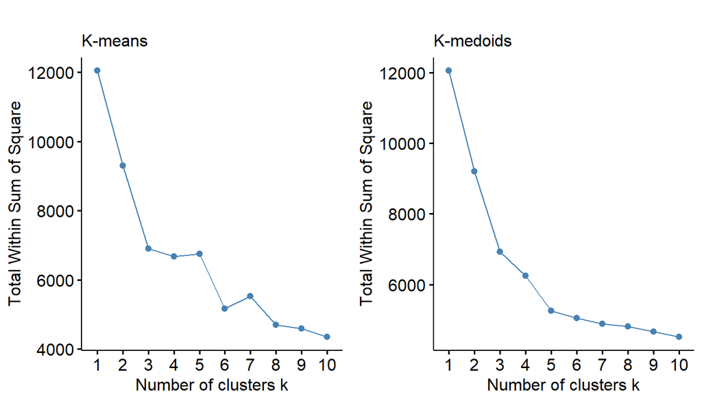

```r
p1_1 + p2_1
```

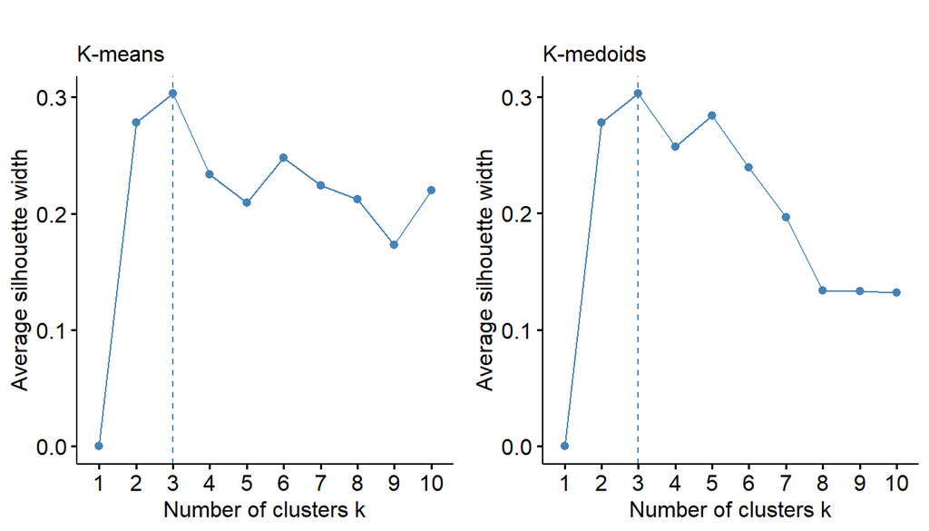

```r
p1_2 + p2_2
```

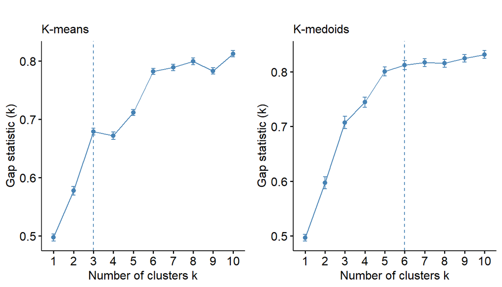

```r
p1_3 + p2_3
```

Dla modelu `k-mean` optymalną liczbą klastrów są 3, jednak warto zwrócić uwagę na wyróżniające się na powyższych wykresach 6 klastrów. W przypadku k-medoidów powyższe statystyki nie są zgodne co do optymalnej liczby klastrów - otrzymujemy odpowiednio 5, 3 i 6. Wydaje się, że 5 klastrów będzie najbardziej optymalne. Możemy jednak na potrzeby zadania porównać przypadki 3 i 6 klastrów w obu metodach, ponieważ także się wyróżniały.

```r
set.seed(123)
km3 <- kmeans(dat, 3)
km6 <- kmeans(dat, 6)
kd3 <- cluster::pam(dat, 3)
kd6 <- cluster::pam(dat, 6)
```

Do porównania otrzymanych klastrów możemy użyć indeksu Jaccarda, który zmierzy podobieństwa klastrów. Wartości bliskie 1 będą oznaczały podobną klasteryzację. Następnie wykorzystamy indeksy Dunna i Daviesa-Bouldina do porównania wyników.

## 2.1 3 klastry

### 2.1.1 Indeks Jaccarda

```r
jc <- cluster_similarity(km3$cluster, kd3$clustering, similarity = "jaccard")
jc
```

```
## [1] 0.9662452
```

Otrzymujemy bardzo wysoki indeks Jaccarda wskazujący na duże podobieństwa pomiędzy klastrami.

### 2.1.2 Indeksy Dunna i Daviesa-Bouldina

```r
dunn1_3 <- clValid::dunn(Data = dat, clusters = km3$cluster)
dunn2_3 <- clValid::dunn(Data = dat, clusters = kd3$clustering)

db1_3 <- clusterSim::index.DB(x = dat, cl = km3$cluster)
db2_3 <- clusterSim::index.DB(x = dat, cl = kd3$clustering)

db1_3 <- db1_3$DB
db2_3 <- db2_3$DB

df<- data.frame("Method" = c("k-means", "k-medoids"), "Dunn" = c(dunn1_3, dunn2_3), "DB" = c(db1_3, db2_3))
df
```

| Method | Dunn | DB |
| --- | --- | --- |
| k-means | 0.2024523 | 1.437868 |
| k-medoids | 0.2024523 | 1.435567 |

Indeksy Dunna są identyczne z dokładnością do aż siedmiu miejsc po przecinku, a indeksy Daviesa-Bouldina różnią się bardzo nieznacznie.

### 2.1.3 Centra

Centra możemy porównać przez sprawdzenie, jak daleko od siebie leżą centra odpowiadających sobie klastrów (przez obliczenie sumy modułów różnic odpowiednich współrzędnych).

```r
kmc3_1 <- km3$centers[1,]
kmc3_2 <- km3$centers[2,]
kmc3_3 <- km3$centers[3,]
kd3_1 <- kd3$medoids[1,]
kd3_2 <- kd3$medoids[2,]
kd3_3 <- kd3$medoids[3,]
sum(abs(kmc3_1 - kd3_3))
```

```
## [1] 7.638588
```

```r
sum(abs(kmc3_2 - kd3_1))
```

```
## [1] 8.98438
```

```r
sum(abs(kmc3_3 - kd3_2))
```

```
## [1] 8.924025
```

Powyżej widzimy, że odległości centrów od siebie są bardzo niewielkie w porównaniu z rozmiarami ramki danych. Stąd centra odpowiednich klastrów leżą blisko siebie.

## 2.2 6 klastrów

### 2.2.1 Indeks Jaccarda

```r
jc <- cluster_similarity(km6$cluster, kd6$clustering, similarity = "jaccard")
jc
```

```
## [1] 0.4783916
```

Tym razem osiągnęliśmy znacznie inną klasteryzację, indeks Jaccarda jest mniejszy niż połowa.

### 2.2.2 Indeksy Dunna i Daviesa-Bouldina

```r
dunn1_6 <- clValid::dunn(Data = dat, clusters = km6$cluster)
dunn2_6 <- clValid::dunn(Data = dat, clusters = kd6$clustering)

db1_6 <- clusterSim::index.DB(x = dat, cl = km6$cluster)
db2_6 <- clusterSim::index.DB(x = dat, cl = kd6$clustering)

db1_6 <- db1_6$DB
db2_6 <- db2_6$DB

df<- data.frame("Method" = c("k-means", "k-medoids"), "Dunn" = c(dunn1_6, dunn2_6), "DB" = c(db1_6, db2_6))
df
```

| Method | Dunn | DB |
| --- | --- | --- |
| k-means | 0.1774296 | 2.045073 |
| k-medoids | 0.1526365 | 1.577935 |

Indeksy Dunna przyjmują bardzo podobne wartości, za to indeks DB wskazuje, że klasteryzacja k-medoidami działa nieco lepiej.

### 2.2.3 Centra

Centra możemy porównać przez sprawdzenie, jak daleko od siebie leżą centra odpowiadających sobie klastrów (przez obliczenie sumy modułów różnic odpowiednich współrzędnych).

```r
kmc6_1 <- km6$centers[1,]
kmc6_2 <- km6$centers[2,]
kmc6_3 <- km6$centers[3,]
kmc6_4 <- km6$centers[4,]
kmc6_5 <- km6$centers[5,]
kmc6_6 <- km6$centers[6,]
kd6_1 <- kd6$medoids[1,]
kd6_2 <- kd6$medoids[2,]
kd6_3 <- kd6$medoids[3,]
kd6_4 <- kd6$medoids[4,]
kd6_5 <- kd6$medoids[5,]
kd6_6 <- kd6$medoids[6,]
sum(abs(kmc6_1 - kd6_1))
```

```
## [1] 23.63589
```

```r
sum(abs(kmc6_2 - kd6_3))
```

```
## [1] 7.638588
```

```r
sum(abs(kmc6_3 - kd6_4))
```

```
## [1] 5.512608
```

```r
sum(abs(kmc6_4 - kd6_5))
```

```
## [1] 8.507294
```

```r
sum(abs(kmc6_5 - kd6_2))
```

```
## [1] 5.903927
```

```r
sum(abs(kmc6_6 - kd6_6))
```

```
## [1] 33.70197
```

```r
# kmc <- data.frame(kmc6_1, kmc6_2, kmc6_3, kmc6_4, kmc6_5, kmc6_6)
# kdc <- data.frame(kd6_1, kd6_2, kd6_3, kd6_4, kd6_5, kd6_6)
# library(combinat)
# perms <- permn(1:6)
# minDist <- Inf
# j <- 0
# for(i in 1:length(perms)){
#   temp <- sum(abs(kmc - kdc[,perms[[i]]]))
#   if(temp < minDist){
#     minDist <- temp
#     j <- i
#   }
# }
# perms[192]
```

Powyższe sumy różnic osiągają najmniejszą sumę spośród wszystkich kombinacji kolumn. Widzimy, że w tym przypadku centra klastrów nie są do siebie podobne. Niestety wykorzystana implementacja k-medoidów nie pozwala na porównanie zbieżności.

# 3 Wizualizacje

Na końcu możemy przyjrzeć się PCA badanego zbioru. Na górnych wykresach kolory odpowiadają klasteryzacji `k-means`, na dolnych `k-medoids`.

## 3.1 3 klastry

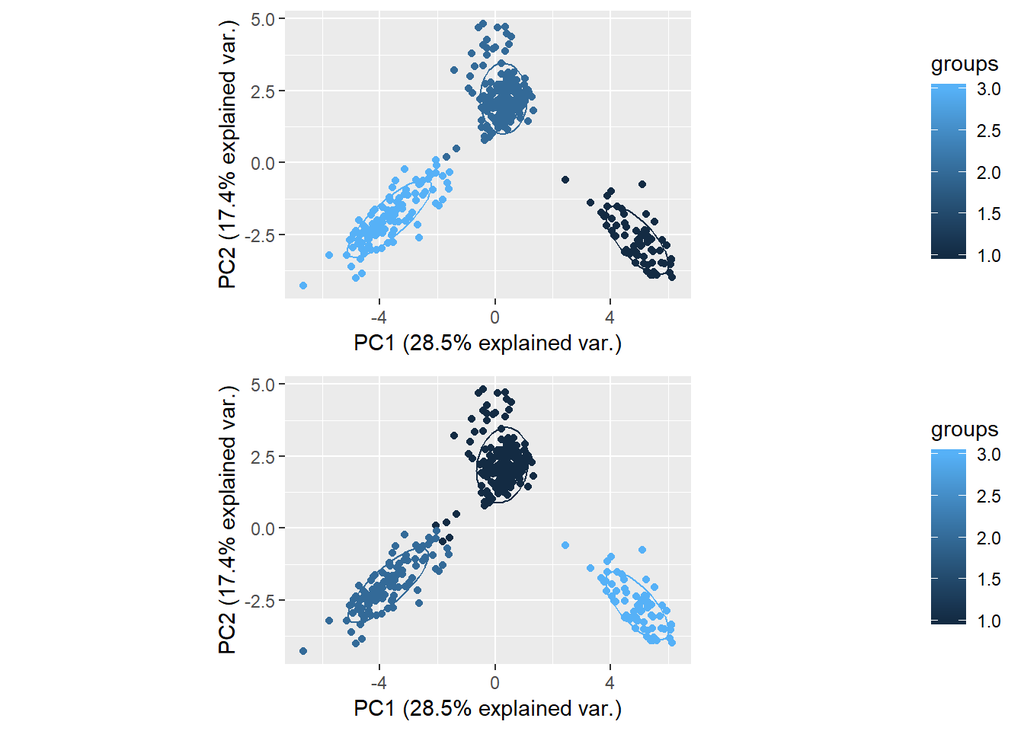

```r
dat3.pca <- prcomp(dat,
                  center = TRUE)

g1 <- ggbiplot(dat3.pca, obs.scale = 1, var.scale = 1,
              groups = km3$cluster, ellipse = TRUE,
              circle = TRUE, var.axes = FALSE, main = "K-means")
g2 <- ggbiplot(dat3.pca, obs.scale = 1, var.scale = 1,
              groups = kd3$clustering, ellipse = TRUE,
              circle = TRUE, var.axes = FALSE, main = "K-medoids")
g1 / g2
```

Przy trzech klastrach klasteryzacje odbyły się prawie identycznie, dobrze odróżniając widoczne na PCA 3 grupy.

## 3.2 6 klastrów

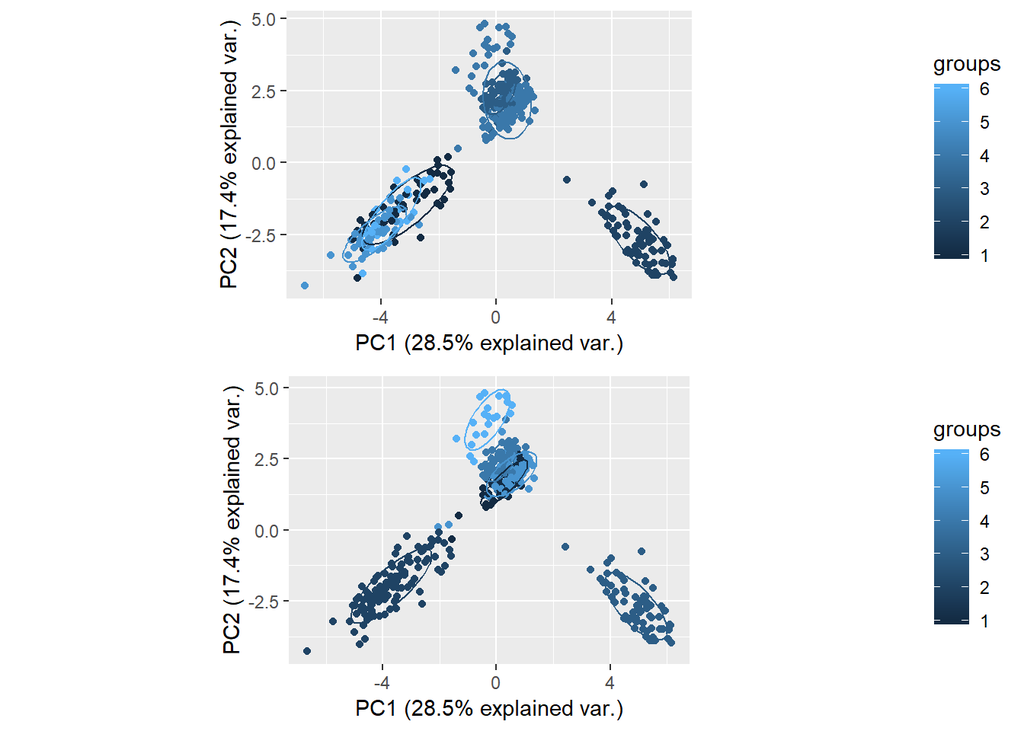

```r
dat3.pca <- prcomp(dat,
                  center = TRUE)

g1 <- ggbiplot(dat3.pca, obs.scale = 1, var.scale = 1,
              groups = km6$cluster, ellipse = TRUE,
              circle = TRUE, var.axes = FALSE, main = "K-means")
g2 <- ggbiplot(dat3.pca, obs.scale = 1, var.scale = 1,
              groups = kd6$clustering, ellipse = TRUE,
              circle = TRUE, var.axes = FALSE, main = "K-medoids")
g1 / g2
```

Dla 6 klastrów algorytmy już różnie poszukiwały klastrów, co widać powyżej.